# Section: Week 6 - Contrasts & Mediation

## Quiz tactics

- Report all relevant statistics (in APA format) – whether significant or not!
- Explain what the stats mean! What is the direction of the effect (e.g., as X increased, Y also increased)? What might be causing those results?
- If describing data, feel free to use bullet points and note the stats + interpretation conscisely if running out of time
- Use R when appropriate to save time, and given extra time write down what you can for credit if you make mistakes (e.g., the code you entered into R; the equations you’d use)
- If you get stuck on a question, move on and come back to it later!
- It’s better to write down something rather than leaving an answer blank. Even if you just write down the equations you would use (or the test more generally), rather than calculating everything.
- If working on homeworks in groups, make sure fully understand each question; try each question on your own before consulting with other people so that you get practice generating how to solve a given problem!

## A note on interactions

Check out this [Nature article](http://www.nature.com/neuro/journal/v14/n9/full/nn.2886.html) about the importance for testing formally for interactions. It’s not enough to say that Group A had a significant positive effect of X and Y, but Group B didn’t; you need to formally test for an interaction between group and X on Y. This is a big error, that is suprisingly made quite often (even in prominent journals like *Science* and *Nature*!).

## Homework Question A

### Define your research question

*Do family-friendly programs in organizations (e.g., flexible work hours, on-site childcare, etc.) have an effect on employee satisfaction?*

Let’s clear out our working space, load in the data, etc.

```r
d=read.csv("http://www.stanford.edu/class/psych252/data/families.csv")
```

### Look at the data

Taking a look at the data.

```r
str(d)
```

```
## 'data.frame':    68 obs. of  3 variables:
##  $ famprog : int  5 9 1 9 3 2 2 2 6 5 ...
##  $ empsatis: num  3.29 5.63 3.92 2.51 5.28 ...
##  $ perfam  : int  66 41 53 54 49 53 70 53 58 43 ...
```

```r
summary(d)
```

```
##     famprog        empsatis        perfam
##  Min.   :1.00   Min.   :2.51   Min.   :36.0
##  1st Qu.:3.00   1st Qu.:3.36   1st Qu.:47.8
##  Median :6.00   Median :3.92   Median :55.0
##  Mean   :5.41   Mean   :3.94   Mean   :55.3
##  3rd Qu.:7.25   3rd Qu.:4.42   3rd Qu.:62.2
##  Max.   :9.00   Max.   :5.63   Max.   :88.0
```

Now we know that we have: `N = 68` companies in our sample

**Measures**

`famprog:` the amount of family-friendly programs from (1) Nothing at all to (9) Amazing family-friendliness

`empsatis:` the average rating of employee satisfaction from (1) Extremely unsatisfied to (7) Extremely satisfied

`perfam:` the percentage of employees with families in the organization from 0% to 100%

**Describe the data**

First let’s summarize the data

```r
describe(d)
```

```
##          vars  n  mean    sd median trimmed   mad   min   max range  skew
## famprog     1 68  5.41  2.52   6.00    5.46  2.97  1.00  9.00  8.00 -0.11
## empsatis    2 68  3.94  0.77   3.92    3.92  0.81  2.51  5.63  3.12  0.32
## perfam      3 68 55.29 10.43  55.00   55.00 11.12 36.00 88.00 52.00  0.34
##          kurtosis   se
## famprog     -1.27 0.31
## empsatis    -0.68 0.09
## perfam       0.07 1.26
```

Now, to look at the relationships between variables, we’ll visualize the data w/plots.

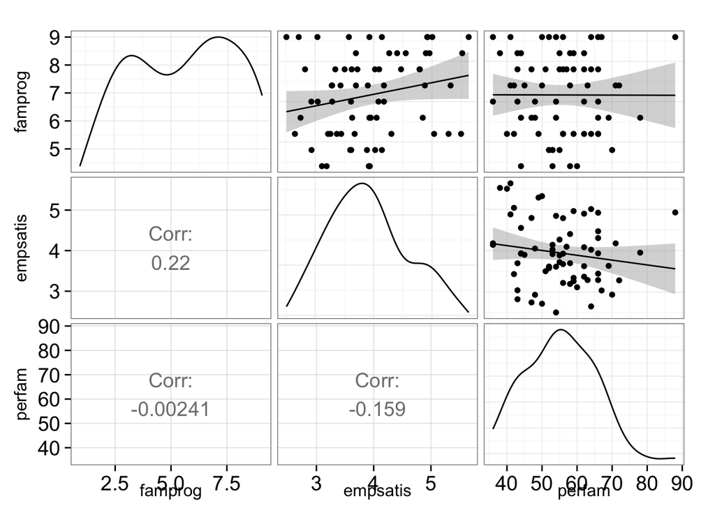

```r
plot_dataframe(d)
```

### Consider main effects

**Main effects: Does the number of programs affect employee satisfaction? Is the percentage of families who use the programs correlated with employee satisfaction?**

First, we could run a simple regression where `famprog`, the number of family-friendly programs, predicts `empsatis`, employee satisfaction:

```r
# Stats
e_by_famprog = lm(empsatis ~ scale(famprog, scale=FALSE), data = d)
summary(e_by_famprog)
```

```
##
## Call:
## lm(formula = empsatis ~ scale(famprog, scale = FALSE), data = d)
##
## Residuals:
##     Min      1Q  Median      3Q     Max
## -1.6779 -0.5365 -0.0348  0.4285  1.7152
##
## Coefficients:
##                               Estimate Std. Error t value Pr(>|t|)
## (Intercept)                     3.9439     0.0915   43.12   <2e-16 ***
## scale(famprog, scale = FALSE)   0.0670     0.0366    1.83    0.072 .
## ---
## Signif. codes:  0 '***' 0.001 '**' 0.01 '*' 0.05 '.' 0.1 ' ' 1
##
## Residual standard error: 0.754 on 66 degrees of freedom
## Multiple R-squared:  0.0484, Adjusted R-squared:  0.034
## F-statistic: 3.36 on 1 and 66 DF,  p-value: 0.0715
```

Seems like the answer is yes, but we have a weak (i.e., **marginal**) effect. Can we do something to describe the data better? Taking a look at our plot, what do we think might be going on?

### Consider interactions (and/or quadratic effects)

We could use our other predictor `perfam`, and look for an interaction with family programs on employee satisfaction:

```r
e_by_famprogXperfam = lm(empsatis ~ scale(famprog, scale=FALSE) *
                           scale(perfam, scale=FALSE), data = d)
summary(e_by_famprogXperfam)
```

```
##
## Call:
## lm(formula = empsatis ~ scale(famprog, scale = FALSE) * scale(perfam,
##     scale = FALSE), data = d)
##
## Residuals:
##     Min      1Q  Median      3Q     Max
## -1.6592 -0.3919 -0.0431  0.4675  1.5906
##
## Coefficients:
##                                                            Estimate
## (Intercept)                                                 3.94433
## scale(famprog, scale = FALSE)                               0.06526
## scale(perfam, scale = FALSE)                               -0.01670
## scale(famprog, scale = FALSE):scale(perfam, scale = FALSE)  0.00740
##                                                            Std. Error
## (Intercept)                                                   0.08875
## scale(famprog, scale = FALSE)                                 0.03553
## scale(perfam, scale = FALSE)                                  0.00892
## scale(famprog, scale = FALSE):scale(perfam, scale = FALSE)    0.00359
##                                                            t value
## (Intercept)                                                  44.44
## scale(famprog, scale = FALSE)                                 1.84
## scale(perfam, scale = FALSE)                                 -1.87
## scale(famprog, scale = FALSE):scale(perfam, scale = FALSE)    2.06
##                                                            Pr(>|t|)
## (Intercept)                                                  <2e-16 ***
## scale(famprog, scale = FALSE)                                 0.071 .
## scale(perfam, scale = FALSE)                                  0.066 .
## scale(famprog, scale = FALSE):scale(perfam, scale = FALSE)    0.044 *
## ---
## Signif. codes:  0 '***' 0.001 '**' 0.01 '*' 0.05 '.' 0.1 ' ' 1
##
## Residual standard error: 0.732 on 64 degrees of freedom
## Multiple R-squared:  0.131,  Adjusted R-squared:  0.0903
## F-statistic: 3.22 on 3 and 64 DF,  p-value: 0.0286
```

```r
# additive model
e_by_famprogplusperfam = lm(empsatis ~ scale(famprog, scale=FALSE) +
                           scale(perfam, scale=FALSE), data = d)

# compare 2 models
anova(e_by_famprogplusperfam, e_by_famprogXperfam)
```

```
## Analysis of Variance Table
##
## Model 1: empsatis ~ scale(famprog, scale = FALSE) + scale(perfam, scale = FALSE)
## Model 2: empsatis ~ scale(famprog, scale = FALSE) * scale(perfam, scale = FALSE)
##   Res.Df  RSS Df Sum of Sq    F Pr(>F)
## 1     65 36.5
## 2     64 34.3  1      2.27 4.24  0.044 *
## ---
## Signif. codes:  0 '***' 0.001 '**' 0.01 '*' 0.05 '.' 0.1 ' ' 1
```

### Visualize the interactions

```r
d$perfam_nMS[ d$perfam < median(d$perfam) ] = 'Low Percentage Families'
d$perfam_nMS[ d$perfam > median(d$perfam) ] = 'High Percentage Families'
d$perfam_nMS = as.factor( d$perfam_nMS )
str(d)
```

```
## 'data.frame':    68 obs. of  4 variables:
##  $ famprog   : int  5 9 1 9 3 2 2 2 6 5 ...
##  $ empsatis  : num  3.29 5.63 3.92 2.51 5.28 ...
##  $ perfam    : int  66 41 53 54 49 53 70 53 58 43 ...
##  $ perfam_nMS: Factor w/ 2 levels "High Percentage Families",..: 1 2 2 2 2 2 1 2 1 2 ...
```

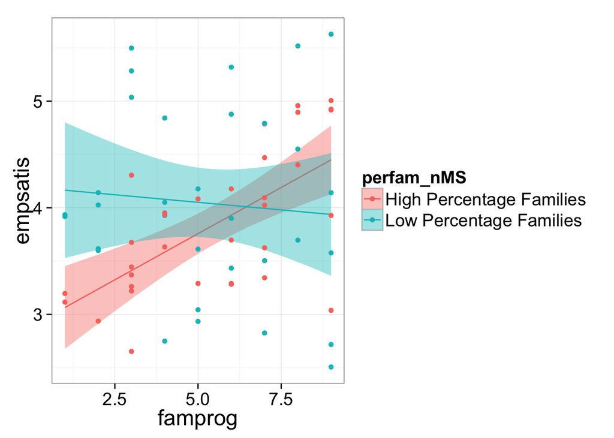

```r
# Begin plotting
ggplot(na.omit(d), aes(famprog, empsatis,
              color = perfam_nMS,
              fill=perfam_nMS)) +
  stat_smooth(method=lm) +
  geom_point()
```

### Write up results

**Make sure to:**

- Use APA format!
- Explain what the results (e.g., p < 0.05) mean; what is the direction of the effect? What have we learned from this analysis?
- Give a brief causal story about why this might be the case

#### Interpret the interaction/higher order effects

**Does the percentage of employees with families impact the effect of family programs on employee satisfaction?**

When examining whether the percentage of employees with families impacts the effect of family programs on employee satisfaction, we observed a significant interaction between the number of family friendly programs and the percentage of employees with families on employee satisfaction, $b=0.007, t(64)=2.06, p < 0.05$. More specifically, for companies that had a low percentage of employees with families, an increase in the number of family friendly programs did not really affect employee satistfaction. However, for companies that had a high percentage of employees with families, the more family friendly programs they had, the higher employee satisfaction was. This is likely the case because employees with families could make better use of the family friendly programs, etc.

### Further explore the interaction

**Interpret the interaction by examining the effect of family programs on employee satisfaction for companies who have the average number of employees with families**

Revisit our centered lm:

```r
at_mean = lm(empsatis ~ scale(famprog, scale = F) *
               scale(perfam, scale = F), data = d)
summary(at_mean)
```

```
##
## Call:
## lm(formula = empsatis ~ scale(famprog, scale = F) * scale(perfam,
##     scale = F), data = d)
##
## Residuals:
##     Min      1Q  Median      3Q     Max
## -1.6592 -0.3919 -0.0431  0.4675  1.5906
##
## Coefficients:
##                                                    Estimate Std. Error
## (Intercept)                                         3.94433    0.08875
## scale(famprog, scale = F)                           0.06526    0.03553
## scale(perfam, scale = F)                           -0.01670    0.00892
## scale(famprog, scale = F):scale(perfam, scale = F)  0.00740    0.00359
##                                                    t value Pr(>|t|)
## (Intercept)                                          44.44   <2e-16 ***
## scale(famprog, scale = F)                             1.84    0.071 .
## scale(perfam, scale = F)                             -1.87    0.066 .
## scale(famprog, scale = F):scale(perfam, scale = F)    2.06    0.044 *
## ---
## Signif. codes:  0 '***' 0.001 '**' 0.01 '*' 0.05 '.' 0.1 ' ' 1
##
## Residual standard error: 0.732 on 64 degrees of freedom
## Multiple R-squared:  0.131,  Adjusted R-squared:  0.0903
## F-statistic: 3.22 on 3 and 64 DF,  p-value: 0.0286
```

```r
# compare to:
# summary(lm(empsatis ~ scale(famprog, scale = F), data = d))
```

Because we’ve centered both variables (0 = mean), the “simple effects” reported here are at the mean of each variable.

So for the effect of family programs on employee satisfaction for companies who have the average number of employees with families, $b = .065, t(64)=1.84, p = .07$. Thus, for companies who have the average number of employees with families, as they increase the number of family friendly programs, employee satisfaction trends toward increasing.

So, what do we mean below by the “main effect” of family programs on employee satisfaction? Lesson: don’t rely on these terms “simple” and “main” effect to make yourself understood. Be clear in describing your interpretation and exactly what it means. This is also helpful in coming up with a good mechanistic interpretation.

**Interpret the interaction by examining the effect of family programs on employee satisfaction for companies at +1SD and -1SD of mean % who use programs**

Say we want to know about companies that have a lot of employees with families who use these programs (+1SD). We calculate this by literally subtracting 1SD from the centered value of `perfam`.

```r
at_plus1SD = lm(empsatis ~ scale(famprog, scale = F) *
                  I(scale(perfam, scale = F)-sd(perfam)), data = d)
summary(at_plus1SD)
```

```
##
## Call:
## lm(formula = empsatis ~ scale(famprog, scale = F) * I(scale(perfam,
##     scale = F) - sd(perfam)), data = d)
##
## Residuals:
##     Min      1Q  Median      3Q     Max
## -1.6592 -0.3919 -0.0431  0.4675  1.5906
##
## Coefficients:
##                                                                    Estimate
## (Intercept)                                                         3.77012
## scale(famprog, scale = F)                                           0.14243
## I(scale(perfam, scale = F) - sd(perfam))                           -0.01670
## scale(famprog, scale = F):I(scale(perfam, scale = F) - sd(perfam))  0.00740
##                                                                    Std. Error
## (Intercept)                                                           0.12851
## scale(famprog, scale = F)                                             0.05105
## I(scale(perfam, scale = F) - sd(perfam))                              0.00892
## scale(famprog, scale = F):I(scale(perfam, scale = F) - sd(perfam))    0.00359
##                                                                    t value
## (Intercept)                                                          29.34
## scale(famprog, scale = F)                                             2.79
## I(scale(perfam, scale = F) - sd(perfam))                             -1.87
## scale(famprog, scale = F):I(scale(perfam, scale = F) - sd(perfam))    2.06
##                                                                    Pr(>|t|)
## (Intercept)                                                          <2e-16
## scale(famprog, scale = F)                                            0.0069
## I(scale(perfam, scale = F) - sd(perfam))                             0.0656
## scale(famprog, scale = F):I(scale(perfam, scale = F) - sd(perfam))   0.0435
##
## (Intercept)                                                        ***
## scale(famprog, scale = F)                                          **
## I(scale(perfam, scale = F) - sd(perfam))                           .
## scale(famprog, scale = F):I(scale(perfam, scale = F) - sd(perfam)) *
## ---
## Signif. codes:  0 '***' 0.001 '**' 0.01 '*' 0.05 '.' 0.1 ' ' 1
##
## Residual standard error: 0.732 on 64 degrees of freedom
## Multiple R-squared:  0.131,  Adjusted R-squared:  0.0903
## F-statistic: 3.22 on 3 and 64 DF,  p-value: 0.0286
```

So for the number of family programs at **+1SD above the mean** of the percentage of families who use programs, the effect of family programs on employee satisfaction is $b = .14, t(64) = 2.79, p < .01.$ Interpret this!

*Remember that we subtract one SD to describe the effect at one SD above the mean! You’re subtracting these levels from your centered variable, so in the case of -1 SD, so +1 SD*

Now, for companies with few families who use these programs, we’ll look at **1SD below the mean** of the percentage of families who use these programs

```r
at_minus1SD = lm(empsatis ~ scale(famprog, scale = F) *
                   I(scale(perfam, scale = F)+sd(perfam)), data = d)
summary(at_minus1SD)
```

```
##
## Call:
## lm(formula = empsatis ~ scale(famprog, scale = F) * I(scale(perfam,
##     scale = F) + sd(perfam)), data = d)
##
## Residuals:
##     Min      1Q  Median      3Q     Max
## -1.6592 -0.3919 -0.0431  0.4675  1.5906
##
## Coefficients:
##                                                                    Estimate
## (Intercept)                                                         4.11854
## scale(famprog, scale = F)                                          -0.01192
## I(scale(perfam, scale = F) + sd(perfam))                           -0.01670
## scale(famprog, scale = F):I(scale(perfam, scale = F) + sd(perfam))  0.00740
##                                                                    Std. Error
## (Intercept)                                                           0.12860
## scale(famprog, scale = F)                                             0.05223
## I(scale(perfam, scale = F) + sd(perfam))                              0.00892
## scale(famprog, scale = F):I(scale(perfam, scale = F) + sd(perfam))    0.00359
##                                                                    t value
## (Intercept)                                                          32.03
## scale(famprog, scale = F)                                            -0.23
## I(scale(perfam, scale = F) + sd(perfam))                             -1.87
## scale(famprog, scale = F):I(scale(perfam, scale = F) + sd(perfam))    2.06
##                                                                    Pr(>|t|)
## (Intercept)                                                          <2e-16
## scale(famprog, scale = F)                                             0.820
## I(scale(perfam, scale = F) + sd(perfam))                              0.066
## scale(famprog, scale = F):I(scale(perfam, scale = F) + sd(perfam))    0.044
##
## (Intercept)                                                        ***
## scale(famprog, scale = F)
## I(scale(perfam, scale = F) + sd(perfam))                           .
## scale(famprog, scale = F):I(scale(perfam, scale = F) + sd(perfam)) *
## ---
## Signif. codes:  0 '***' 0.001 '**' 0.01 '*' 0.05 '.' 0.1 ' ' 1
##
## Residual standard error: 0.732 on 64 degrees of freedom
## Multiple R-squared:  0.131,  Adjusted R-squared:  0.0903
## F-statistic: 3.22 on 3 and 64 DF,  p-value: 0.0286
```

$b = -.01, t(64)=-0.23, p=0.82$ Interpret this!

**Answer**: List the simple effects at each level of `perfam`.

#### Visualize the interaction/simple effects

We can also plot these specific results to visualize the continuous interaction (specifically the simple effects of famprog at +/- 1SD of perfam) using the regression equations from above.

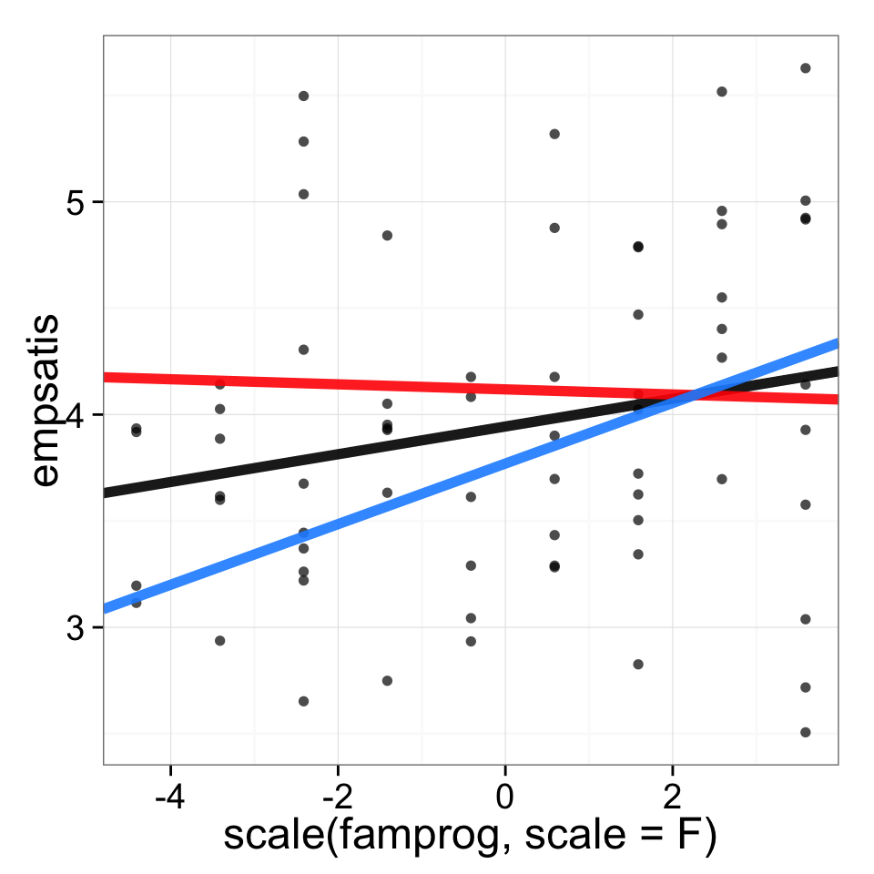

```r
ggplot(d,
       aes(x=scale(famprog, scale=F),
           y=empsatis)) +  # Adding color for mentill
  geom_point(alpha=0.7) +
  # effect of famprog on empsatis @mean perfam
  geom_abline(aes(intercept=at_mean$coefficients[1],
                  slope=at_mean$coefficients[2]), colour='black', size=2, alpha=.9) +
  # effect of famprog on empsatis -1 SD perfam
  geom_abline(aes(intercept=at_minus1SD$coefficients[1],
                  slope=at_minus1SD$coefficients[2]), colour='red', size=2, alpha=.9) +
  # effect of famprog on empsatis +1 SD perfam
  geom_abline(aes(intercept=at_plus1SD$coefficients[1],
                  slope=at_plus1SD$coefficients[2]), colour='dodgerblue', size=2, alpha=.9)
```

Alternately, get the plot just using the original model:

```
##
## Call:
## lm(formula = empsatis ~ perfam_c * famprog_c, data = d)
##
## Residuals:
##     Min      1Q  Median      3Q     Max
## -1.6592 -0.3919 -0.0431  0.4675  1.5906
##
## Coefficients:
##                    Estimate Std. Error t value Pr(>|t|)
## (Intercept)         3.94433    0.08875   44.44   <2e-16 ***
## perfam_c           -0.01670    0.00892   -1.87    0.066 .
## famprog_c           0.06526    0.03553    1.84    0.071 .
## perfam_c:famprog_c  0.00740    0.00359    2.06    0.044 *
## ---
## Signif. codes:  0 '***' 0.001 '**' 0.01 '*' 0.05 '.' 0.1 ' ' 1
##
## Residual standard error: 0.732 on 64 degrees of freedom
## Multiple R-squared:  0.131,  Adjusted R-squared:  0.0903
## F-statistic: 3.22 on 3 and 64 DF,  p-value: 0.0286
```

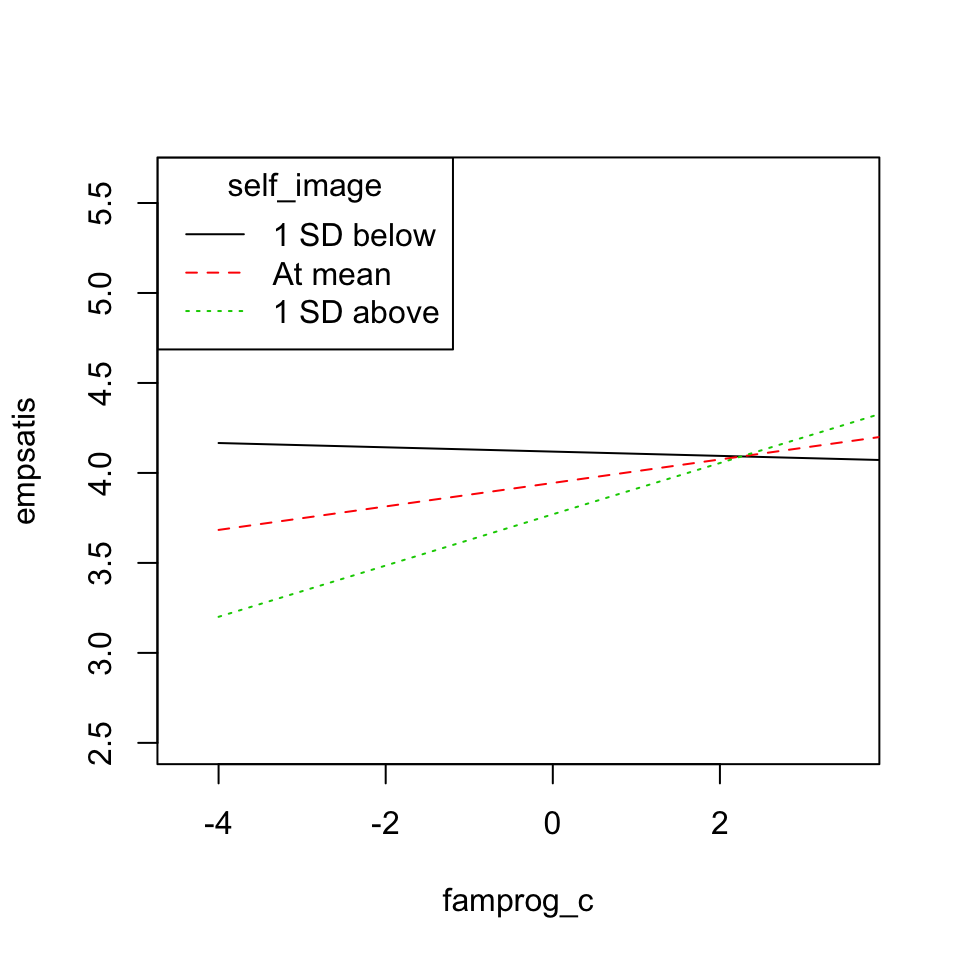

### Return to the main/simple effects

**Do family-friendly programs improve employee satisfaction overall?**

Since we’ve centered our variables, we can essentially interpret the lower order terms as main effects. You can compute the main effects with separate models too, e.g., `lm(empsatis ~ scale(famprog, scale=FALSE) * , data = d)`.

Answer: Yes, there is a marginal positive main effect of the number of family programs on employee satisfaction, and we would report the b, t, df, and p, and then give a short interpretation of the results (e.g., “as __ increases, __ also increases.”) `b = .07, t(64) = 1.84, p = .07`

### Conclusion

**What do you conclude? Write out the story. Remember to use the appropriate numbers to make the story as useful as possible!**

```r
mean(d$perfam)
```

```
## [1] 55.29
```

```r
mean(d$perfam)+sd(d$perfam)
```

```
## [1] 65.73
```

```r
mean(d$perfam)-sd(d$perfam)
```

```
## [1] 44.86
```

## Coding categorical variables

Contrast/effect/dummy coding can often be useful when including categorical variables as predictors in a general linear model. For a given variable, we can have $k-1$ contrasts (where $k$ is the number of levels).

### Converting from continuous to categorical variables

Let’s say that we had predictor(s) that were categorical variables. For an example, we’ll continue with this dataset, though note we would probably want to treat these variables as continuous rather than categorical (or at least as “ordinal”) if doing research!

```r
quantpf3 = quantile(d$perfam, probs = c(.34, .66)); print(quantpf3)
```

```
##   34%   66%
## 51.78 59.00
```

```r
d$perfamcat = findInterval(d$perfam, quantpf3)

table(d$perfamcat)
```

```
##
##  0  1  2
## 23 20 25
```

```r
str(d)
```

```
## 'data.frame':    68 obs. of  7 variables:
##  $ famprog   : int  5 9 1 9 3 2 2 2 6 5 ...
##  $ empsatis  : num  3.29 5.63 3.92 2.51 5.28 ...
##  $ perfam    : int  66 41 53 54 49 53 70 53 58 43 ...
##  $ perfam_nMS: Factor w/ 2 levels "High Percentage Families",..: 1 2 2 2 2 2 1 2 1 2 ...
##  $ famprog_c : num  -0.412 3.588 -4.412 3.588 -2.412 ...
##  $ perfam_c  : num  10.71 -14.29 -2.29 -1.29 -6.29 ...
##  $ perfamcat : int  2 0 1 1 0 1 2 1 1 0 ...
```

```r
d$PerCat <- factor(d$perfamcat, labels=c('low fam','middle fam', 'high fam'))
# table(d$PerCat)
```

Similarly, we’ll convert `famprog` into a categorical variable using the median to split the variable into “low family programs” and “high family programs”.

```r
quantfp2 = median(d$famprog)
print(quantfp2)
```

```
## [1] 6
```

```r
d$famprogcat = findInterval(d$famprog, quantfp2)

table(d$famprogcat)
```

```
##
##  0  1
## 33 35
```

```r
d$FPcat <- factor(d$famprogcat, labels = c("lowprog", "highprog"))
```

```r
str(d) # note variables that are chr not factor! problem for contrasts
```

```
## 'data.frame':    68 obs. of  10 variables:
##  $ famprog   : int  5 9 1 9 3 2 2 2 6 5 ...
##  $ empsatis  : num  3.29 5.63 3.92 2.51 5.28 ...
##  $ perfam    : int  66 41 53 54 49 53 70 53 58 43 ...
##  $ perfam_nMS: Factor w/ 2 levels "High Percentage Families",..: 1 2 2 2 2 2 1 2 1 2 ...
##  $ famprog_c : num  -0.412 3.588 -4.412 3.588 -2.412 ...
##  $ perfam_c  : num  10.71 -14.29 -2.29 -1.29 -6.29 ...
##  $ perfamcat : int  2 0 1 1 0 1 2 1 1 0 ...
##  $ PerCat    : Factor w/ 3 levels "low fam","middle fam",..: 3 1 2 2 1 2 3 2 2 1 ...
##  $ famprogcat: int  0 1 0 1 0 0 0 0 1 0 ...
##  $ FPcat     : Factor w/ 2 levels "lowprog","highprog": 1 2 1 2 1 1 1 1 2 1 ...
```

```r
# contrasts(d$Fcat)=cbind(-1,1)
```

Let’s plot our data!

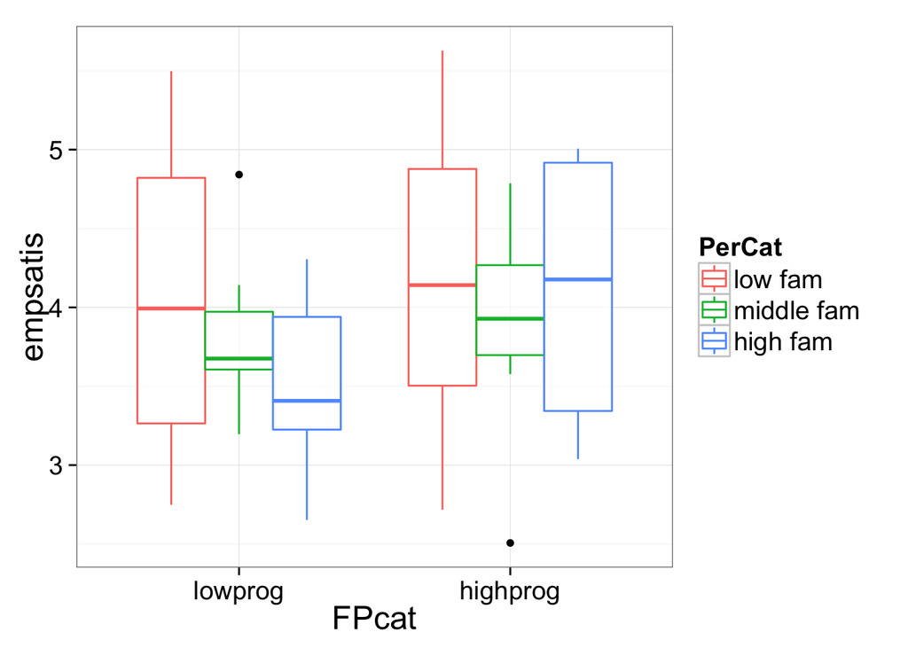

```r
ggplot(d, aes(x=FPcat, y=empsatis, color=PerCat)) +
  geom_boxplot(alpha=.7)
```

How can we make bar graphs? (Since we’re using two categorical predictors)

We’ll also add error bars! We’ll include a formula for the standard error that you could use.

```r
sem <- function(x) {sd(x) / sqrt(length(x))}
```

```r
ms <- aggregate(empsatis ~ FPcat + PerCat, data=d, mean)
ms$errs <- aggregate(empsatis ~ FPcat + PerCat, data=d, sem)$empsatis
print(ms)
```

```
##      FPcat     PerCat empsatis   errs
## 1  lowprog    low fam    4.063 0.3088
## 2 highprog    low fam    4.223 0.2710
## 3  lowprog middle fam    3.794 0.1382
## 4 highprog middle fam    3.887 0.2150
## 5  lowprog   high fam    3.498 0.1431
## 6 highprog   high fam    4.150 0.2103
```

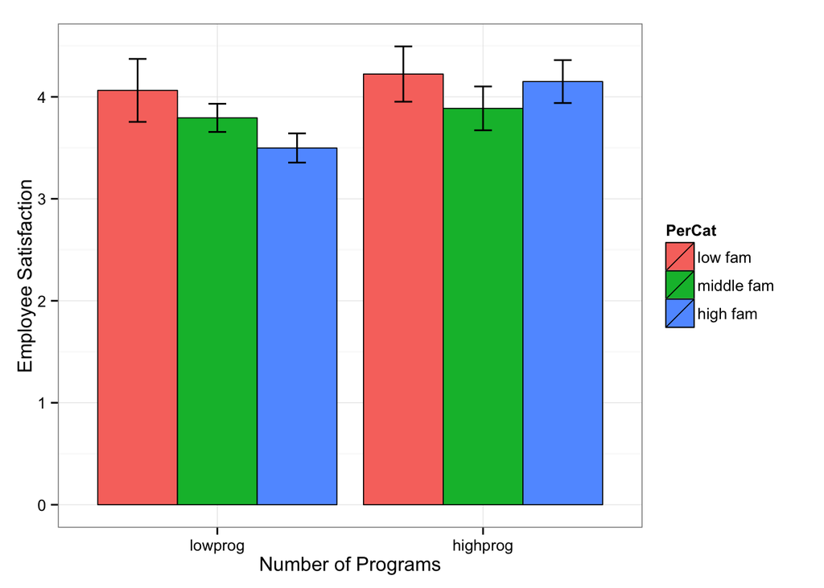

```r
ggplot(ms, aes(x=FPcat, y=empsatis, fill=PerCat)) +
  geom_bar(position=position_dodge(), stat="identity", colour="black", size=.3) + # Use black outlines
  geom_errorbar(aes(ymin = ms$empsatis-ms$errs, ymax=ms$empsatis+ms$errs), width=.2, position=position_dodge(width=.9)) +
  xlab("Number of Programs") +
  ylab("Employee Satisfaction") +
  theme_bw()
```

### Generate a hypothesis

Contrasts can often be helpful because **you can make really specific predictions about trends in your data**. For instance, you might think (1) group A and group D should should a positive effect, and group B and group C might have a negative effect, and (2) that group B has a greater effect than group C, etc. Using an ANOVA, we can just test if the groups are different from each other, but not specific patterns of *how* they differ. However, using contrasts, we can look for specific patterns! Here, it’s often useful (and recommended) that you generate a hypothesis for what pattern you would expect to see before making random contrasts and testing them!

Let’s revisit our data, but just take a look at the companies that had a low number of programs, since that seemed to be where interesting things were happening!

```r
l = subset(d, FPcat=='lowprog')
str(l)
```

```
## 'data.frame':    33 obs. of  10 variables:
##  $ famprog   : int  5 1 3 2 2 2 5 3 4 1 ...
##  $ empsatis  : num  3.29 3.92 5.28 4.03 2.94 ...
##  $ perfam    : int  66 53 49 53 70 53 43 42 44 44 ...
##  $ perfam_nMS: Factor w/ 2 levels "High Percentage Families",..: 1 2 2 2 1 2 2 2 2 2 ...
##  $ famprog_c : num  -0.412 -4.412 -2.412 -3.412 -3.412 ...
##  $ perfam_c  : num  10.71 -2.29 -6.29 -2.29 14.71 ...
##  $ perfamcat : int  2 1 0 1 2 1 0 0 0 0 ...
##  $ PerCat    : Factor w/ 3 levels "low fam","middle fam",..: 3 2 1 2 3 2 1 1 1 1 ...
##  $ famprogcat: int  0 0 0 0 0 0 0 0 0 0 ...
##  $ FPcat     : Factor w/ 2 levels "lowprog","highprog": 1 1 1 1 1 1 1 1 1 1 ...
```

What if we change our contrasts? What predictions might we make using the data?

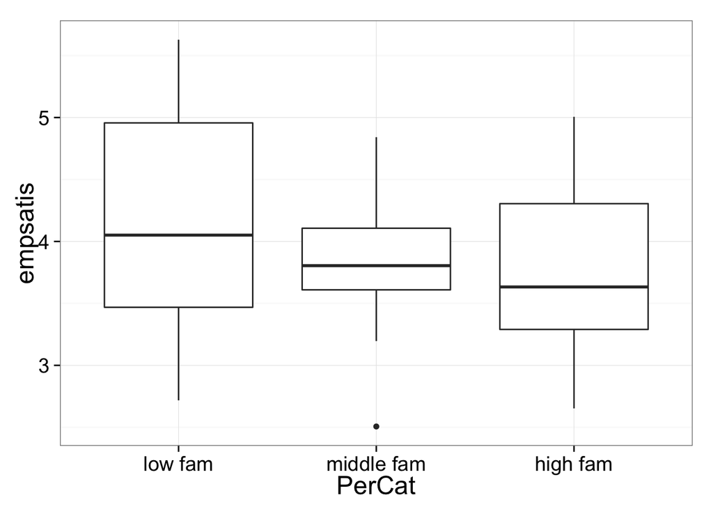

```r
qplot(PerCat, empsatis, data = d, geom = "boxplot")
```

```r
levels(l$PerCat)
```

```
## [1] "low fam"    "middle fam" "high fam"
```

```r
# here' are the's the default coding:
contrasts(l$PerCat)
```

```
##            middle fam high fam
## low fam             0        0
## middle fam          1        0
## high fam            0        1
```

```r
# now let's change it
contrasts(l$PerCat) = cbind(hiVSother = c(1,1,-2), lowVSmid = c(1,-1,0)) #which groups are these contrasts comparing?
contrasts(l$PerCat)
```

```
##            hiVSother lowVSmid
## low fam            1        1
## middle fam         1       -1
## high fam          -2        0
```

```r
with(l, summary(lm(empsatis ~ PerCat)))
```

```
##
## Call:
## lm(formula = empsatis ~ PerCat)
##
## Residuals:
##    Min     1Q Median     3Q    Max
## -1.315 -0.237 -0.119  0.348  1.434
##
## Coefficients:
##                 Estimate Std. Error t value Pr(>|t|)
## (Intercept)       3.7852     0.1166   32.46   <2e-16 ***
## PerCathiVSother   0.1434     0.0806    1.78    0.085 .
## PerCatlowVSmid    0.1346     0.1459    0.92    0.364
## ---
## Signif. codes:  0 '***' 0.001 '**' 0.01 '*' 0.05 '.' 0.1 ' ' 1
##
## Residual standard error: 0.668 on 30 degrees of freedom
## Multiple R-squared:  0.116,  Adjusted R-squared:  0.0568
## F-statistic: 1.96 on 2 and 30 DF,  p-value: 0.158
```

### Interpreting our contrasts

Here, our first contrast (hiVSother) compares “high fam” to the average of “low” and “middle fam”. Our second contrast (which is nested in our first contrast) compares “low fam” to “middle fam”. They are orthogonal because the products of the elements in the contrasts sums to zero ($1*1 + 1*-1 + -2*0 = 0$).

### Orthogonality

We’ve talked in class about contrasts that are orthogonal. In general, the elements in a contrasts should sum to zero (e.g., `sum(c(-1, 1)) = 0`), but in order to be orthogonal, the product of the elements in each contrast should sum to zero. In other words, for two contrasts $a$ and $b$, each of length $t$:

$\sum\limits_{i=1}^t a_i b_i = 0$

Why do we want to create orthogonal contrasts?

```r
res = lm(empsatis ~ PerCat, data=l)
summary(res)
```

```
##
## Call:
## lm(formula = empsatis ~ PerCat, data = l)
##
## Residuals:
##    Min     1Q Median     3Q    Max
## -1.315 -0.237 -0.119  0.348  1.434
##
## Coefficients:
##                 Estimate Std. Error t value Pr(>|t|)
## (Intercept)       3.7852     0.1166   32.46   <2e-16 ***
## PerCathiVSother   0.1434     0.0806    1.78    0.085 .
## PerCatlowVSmid    0.1346     0.1459    0.92    0.364
## ---
## Signif. codes:  0 '***' 0.001 '**' 0.01 '*' 0.05 '.' 0.1 ' ' 1
##
## Residual standard error: 0.668 on 30 degrees of freedom
## Multiple R-squared:  0.116,  Adjusted R-squared:  0.0568
## F-statistic: 1.96 on 2 and 30 DF,  p-value: 0.158
```

```r
contrasts(l$PerCat)
```

```
##            hiVSother lowVSmid
## low fam            1        1
## middle fam         1       -1
## high fam          -2        0
```

```r
designmat = data.frame(model.matrix(res))
head(l)
```

```
##   famprog empsatis perfam               perfam_nMS famprog_c perfam_c
## 1       5    3.290     66 High Percentage Families   -0.4118   10.706
## 3       1    3.918     53  Low Percentage Families   -4.4118   -2.294
## 5       3    5.283     49  Low Percentage Families   -2.4118   -6.294
## 6       2    4.026     53  Low Percentage Families   -3.4118   -2.294
## 7       2    2.937     70 High Percentage Families   -3.4118   14.706
## 8       2    4.142     53  Low Percentage Families   -3.4118   -2.294
##   perfamcat     PerCat famprogcat   FPcat
## 1         2   high fam          0 lowprog
## 3         1 middle fam          0 lowprog
## 5         0    low fam          0 lowprog
## 6         1 middle fam          0 lowprog
## 7         2   high fam          0 lowprog
## 8         1 middle fam          0 lowprog
```

```r
head(designmat)
```

```
##   X.Intercept. PerCathiVSother PerCatlowVSmid
## 1            1              -2              0
## 3            1               1             -1
## 5            1               1              1
## 6            1               1             -1
## 7            1              -2              0
## 8            1               1             -1
```

Let’s create some orthogonal and non-orthogonal contrasts and see which are which!

```r
c(-2,1,1) %*% c(0,1,-1)
```

```
##      [,1]
## [1,]    0
```

```r
c1 <- cbind(c(-2,1,1), c(0,1,-1)); sum(c1[,1] * c1[,2])
```

```
## [1] 0
```

```r
c2 <- cbind(c(-2,1,1), c(1,1,-2)); sum(c2[,1] * c2[,2])
```

```
## [1] -3
```

```r
c3 <- cbind(c(-2,1,1), c(1,1,-3)); sum(c3[,1] * c3[,2])
```

```
## [1] -4
```

```r
c1 <- cbind(c(-3,1,1,1), c(0,0,1,-1), c(-1,1,1,-1)); c1
```

```
##      [,1] [,2] [,3]
## [1,]   -3    0   -1
## [2,]    1    0    1
## [3,]    1    1    1
## [4,]    1   -1   -1
```

```r
c2 <- cbind(c(1,1,-1,-1), c(1,-1,1,-1), c(-1,1,1,-1)); c2
```

```
##      [,1] [,2] [,3]
## [1,]    1    1   -1
## [2,]    1   -1    1
## [3,]   -1    1    1
## [4,]   -1   -1   -1
```

Let’s take a closer look at each of these contrasts to see what groups they would be comparing!

### More on contrasts

In this dataset the researchers were interested in the effect of vitamin C on tooth grown in guinea pigs. Our dataframe has info about tooth length (`len`), the supplement which was administered (`supp`: orange juice (OJ) or ascorbic acid (VC)), and the doseage in mg (`dose`), which we’ll recode as “low”, “med”, and “high”.

```r
data(ToothGrowth)
df = data.frame(ToothGrowth)
df$dose = factor(df$dose,
                 levels=c(0.5,1.0,2.0),
                 labels=c("low","med","high"))
str(df)
```

```
## 'data.frame':    60 obs. of  3 variables:
##  $ len : num  4.2 11.5 7.3 5.8 6.4 10 11.2 11.2 5.2 7 ...
##  $ supp: Factor w/ 2 levels "OJ","VC": 2 2 2 2 2 2 2 2 2 2 ...
##  $ dose: Factor w/ 3 levels "low","med","high": 1 1 1 1 1 1 1 1 1 1 ...
```

#### Effect coding

```r
contrasts(df$supp) = cbind(OJvsVC=c(1, -1)); contrasts(df$supp)
```

```
##    OJvsVC
## OJ      1
## VC     -1
```

```r
contrasts(df$dose) = cbind(C1=c(1, -1, 0),
                           C2=c(0, -1, 1)); contrasts(df$dose)
```

```
##      C1 C2
## low   1  0
## med  -1 -1
## high  0  1
```

```r
summary(lm(len ~ supp + dose, data=df))
```

```
##
## Call:
## lm(formula = len ~ supp + dose, data = df)
##
## Residuals:
##    Min     1Q Median     3Q    Max
##  -7.08  -2.75  -0.80   2.45   9.65
##
## Coefficients:
##             Estimate Std. Error t value Pr(>|t|)
## (Intercept)   18.813      0.494   38.07  < 2e-16 ***
## suppOJvsVC     1.850      0.494    3.74  0.00043 ***
## doseC1        -8.208      0.699  -11.75  < 2e-16 ***
## doseC2         7.287      0.699   10.43  9.8e-15 ***
## ---
## Signif. codes:  0 '***' 0.001 '**' 0.01 '*' 0.05 '.' 0.1 ' ' 1
##
## Residual standard error: 3.83 on 56 degrees of freedom
## Multiple R-squared:  0.762,  Adjusted R-squared:  0.75
## F-statistic: 59.9 on 3 and 56 DF,  p-value: <2e-16
```

```r
with(df, tapply(len, list(dose), mean)) # means by group
```

```
##   low   med  high
## 10.61 19.73 26.10
```

```r
mean(df$len) #unweighted grand mean
```

```
## [1] 18.81
```

Here, our intercept is our (unweighted) “grand mean” of tooth length (it’s weighted if the cell counts are balanced). Then, for our dose constrasts, C1 indicates the difference of “low” from the grand mean ($18.8133-8.2083=10.6$), and C2 indicates the difference of “high” from the grand mean ($18.8133+7.2867=26.1$). Thus, we can say that those with low doses (collapsing across the supplement) had significantly less tooth growth than average [**interpretation of effect!**], $b=-8.21, t(56)=-11.75, p < 0.001$ [**stats!**]. This might be because vitamin C promotes tooth growth [**causal story!**]. However, those with high doses had more tooth growth than average, $b=7.29, t(56)=10.43, p < 0.01$.

Another way to look at the contrasts is as a weighted combination of the group means. Here, we have to take the inverse of R’s contrast codes, and we get the weights for each group:

```r
tmp <- contrasts(df$dose)
tmp <- cbind(constant=1,tmp) # add an intercept (1s)
weights = solve(tmp); weights
```

```
##              low     med    high
## constant  0.3333  0.3333  0.3333
## C1        0.6667 -0.3333 -0.3333
## C2       -0.3333 -0.3333  0.6667
```

**intercept estimate** = .333 * low + .333 * med + .333 * high

**C1 estimate** = .666 * low + -.333 * med + -.333 * high = low - (low + med + high)/3

**C2 estimate** = -.333 * low + -.333 * med + .666 * high = high - (low + med + high)/3

```r
means = with(df, tapply(len, list(dose), mean)) # means by group
means
```

```
##   low   med  high
## 10.61 19.73 26.10
```

```r
sum(means * weights[1,]) # intercept
```

```
## [1] 18.81
```

```r
sum(means * weights[2,]) # C1
```

```
## [1] -8.208
```

```r
sum(means * weights[3,]) # C2
```

```
## [1] 7.287
```

Now, let’s turn to using **contrast coding** to test specific predictions! These should be decided *a priori*, and are thus often called “**planned comparisons**”.

#### Contrast coding

```r
contrasts(df$supp) = cbind(OJvsVC=c(1, -1)); contrasts(df$supp)
```

```
##    OJvsVC
## OJ      1
## VC     -1
```

```r
contrasts(df$dose) = cbind(OTHERvsLOW=c(-2, 1, 1),
                           HIGHvsMED=c(0, -1, 1)); contrasts(df$dose)
```

```
##      OTHERvsLOW HIGHvsMED
## low          -2         0
## med           1        -1
## high          1         1
```

```r
res = lm(len ~ supp * dose, data=df)
anova(res)
```

```
## Analysis of Variance Table
##
## Response: len
##           Df Sum Sq Mean Sq F value  Pr(>F)
## supp       1    205     205   15.57 0.00023 ***
## dose       2   2426    1213   92.00 < 2e-16 ***
## supp:dose  2    108      54    4.11 0.02186 *
## Residuals 54    712      13
## ---
## Signif. codes:  0 '***' 0.001 '**' 0.01 '*' 0.05 '.' 0.1 ' ' 1
```

```r
# Compare with aov
summary(aov(len ~ supp * dose, data=df))
```

```
##             Df Sum Sq Mean Sq F value  Pr(>F)
## supp         1    205     205   15.57 0.00023 ***
## dose         2   2426    1213   92.00 < 2e-16 ***
## supp:dose    2    108      54    4.11 0.02186 *
## Residuals   54    712      13
## ---
## Signif. codes:  0 '***' 0.001 '**' 0.01 '*' 0.05 '.' 0.1 ' ' 1
```

```r
summary(res)
```

```
##
## Call:
## lm(formula = len ~ supp * dose, data = df)
##
## Residuals:
##    Min     1Q Median     3Q    Max
##  -8.20  -2.72  -0.27   2.65   8.27
##
## Coefficients:
##                           Estimate Std. Error t value Pr(>|t|)
## (Intercept)                 18.813      0.469   40.13  < 2e-16 ***
## suppOJvsVC                   1.850      0.469    3.95  0.00023 ***
## doseOTHERvsLOW               4.104      0.332   12.38  < 2e-16 ***
## doseHIGHvsMED                3.183      0.574    5.54  9.1e-07 ***
## suppOJvsVC:doseOTHERvsLOW   -0.388      0.332   -1.17  0.24757
## suppOJvsVC:doseHIGHvsMED    -1.502      0.574   -2.62  0.01149 *
## ---
## Signif. codes:  0 '***' 0.001 '**' 0.01 '*' 0.05 '.' 0.1 ' ' 1
##
## Residual standard error: 3.63 on 54 degrees of freedom
## Multiple R-squared:  0.794,  Adjusted R-squared:  0.775
## F-statistic: 41.6 on 5 and 54 DF,  p-value: <2e-16
```

Here, our doseOTHERvsLOW contrast shows us that the low dose group has significantly lower tooth growth than the other two groups, $b=4.10, t(54)=12.38, p < 0.01$. Further, the doseHIGHvsMED contrast shows us that the high dose group has more tooth growth than the medium group, $b=3.18, t(54)=5.54, p < 0.01.$

Let’s try to recreate our group means using the output!

```r
contrasts(df$supp)
```

```
##    OJvsVC
## OJ      1
## VC     -1
```

```r
contrasts(df$dose)
```

```
##      OTHERvsLOW HIGHvsMED
## low          -2         0
## med           1        -1
## high          1         1
```

```r
OJ_low = 18.8133 + 1.8500*1 + 4.1042*-2 + 3.1825*0 + -0.3875*1*-2 + -1.5025*1*0
OJ_med = 18.8133 + 1.8500*1 + 4.1042*1 + 3.1825*-1 + -0.3875*1*1 + -1.5025*1*-1
OJ_high = 18.8133 + 1.8500*1 + 4.1042*1 + 3.1825*1 + -0.3875*1*1 + -1.5025*1*1

VC_low = 18.8133 + 1.8500*-1 + 4.1042*-2 + 3.1825*0 + -0.3875*-1*-2 + -1.5025*-1*0
VC_med = 18.8133 + 1.8500*-1 + 4.1042*1 + 3.1825*-1 + -0.3875*-1*1 + -1.5025*-1*-1
VC_high = 18.8133 + 1.8500*-1 + 4.1042*1 + 3.1825*1 + -0.3875*-1*1 + -1.5025*-1*1
```

Now we’ll compare these predicted means with the actual means!

```r
rbind(OJ = c(OJ_low, OJ_med, OJ_high), VC = c(VC_low, VC_med, VC_high))
```

```
##     [,1]  [,2]  [,3]
## OJ 13.23 22.70 26.06
## VC  7.98 16.77 26.14
```

```r
with(df, tapply(len, list(supp,dose), mean))
```

```
##      low   med  high
## OJ 13.23 22.70 26.06
## VC  7.98 16.77 26.14
```

Since the contrasts are orthogonal, our predictors aren’t correlated!

```r
designmat = data.frame(model.matrix(res))
cor(designmat)
```

```
##                           X.Intercept. suppOJvsVC doseOTHERvsLOW
## X.Intercept.                         1         NA             NA
## suppOJvsVC                          NA          1              0
## doseOTHERvsLOW                      NA          0              1
## doseHIGHvsMED                       NA          0              0
## suppOJvsVC.doseOTHERvsLOW           NA          0              0
## suppOJvsVC.doseHIGHvsMED            NA          0              0
##                           doseHIGHvsMED suppOJvsVC.doseOTHERvsLOW
## X.Intercept.                         NA                        NA
## suppOJvsVC                            0                         0
## doseOTHERvsLOW                        0                         0
## doseHIGHvsMED                         1                         0
## suppOJvsVC.doseOTHERvsLOW             0                         1
## suppOJvsVC.doseHIGHvsMED              0                         0
##                           suppOJvsVC.doseHIGHvsMED
## X.Intercept.                                    NA
## suppOJvsVC                                       0
## doseOTHERvsLOW                                   0
## doseHIGHvsMED                                    0
## suppOJvsVC.doseOTHERvsLOW                        0
## suppOJvsVC.doseHIGHvsMED                         1
```

Again, another way to look at the contrasts is as a weighted combination of the group means. Here, we have to take the inverse of R’s contrast codes, and we get the weights for each group:

```r
tmp <- contrasts(df$dose)
tmp <- cbind(constant=1,tmp) # add an intercept (1s)
weights = solve(tmp); weights
```

```
##                low     med   high
## constant    0.3333  0.3333 0.3333
## OTHERvsLOW -0.3333  0.1667 0.1667
## HIGHvsMED   0.0000 -0.5000 0.5000
```

**intercept estimate** = .333 * low + .333 * med + .333 * high

**OTHERvsLOW estimate** = -.333 * low + 0.167 * med + 0.167 * high

**HIGHvsMED estimate** = 0 * low + -.5 * med + .5 * high

```r
coef(res)
```

```
##               (Intercept)                suppOJvsVC
##                   18.8133                    1.8500
##            doseOTHERvsLOW             doseHIGHvsMED
##                    4.1042                    3.1825
## suppOJvsVC:doseOTHERvsLOW  suppOJvsVC:doseHIGHvsMED
##                   -0.3875                   -1.5025
```

```r
sum(means * weights[1,]) # intercept
```

```
## [1] 18.81
```

```r
sum(means * weights[2,]) # OTHERvsLOW
```

```
## [1] 4.104
```

```r
sum(means * weights[3,]) # HIGHvsMED
```

```
## [1] 3.183
```

## Mediation (Question E)

Let’s clean up our screens and load in the next data set!

```r
# rm(list=ls())

d = read.csv('http://www.stanford.edu/class/psych252/data/caffeine.csv')
str(d)
```

```
## 'data.frame':    62 obs. of  4 variables:
##  $ coffee : int  1 1 1 1 2 1 1 1 2 1 ...
##  $ perf   : int  53 9 31 38 40 40 9 37 62 23 ...
##  $ accur  : num  0.45 0.5 0.499 0.454 0.421 ...
##  $ numprob: int  7 6 6 7 8 6 6 8 7 7 ...
```

**Measures**

What mediational question might we ask with these data?

**IV**: *Coffee* - 20 subjects in each group either had 0 cups, 2 cups, or 4 cups

**DV**: *Performance* - on a stats quiz with 10 problems, 5-89 points

**Possible Mediator 1**: *Number of problems attempted* (hyperactivity)

**Possible Mediator 2**: *Accuracy* - how likely they were to get a problem right if they tried (better success)

What should we do first?

Let’s visualize the data:

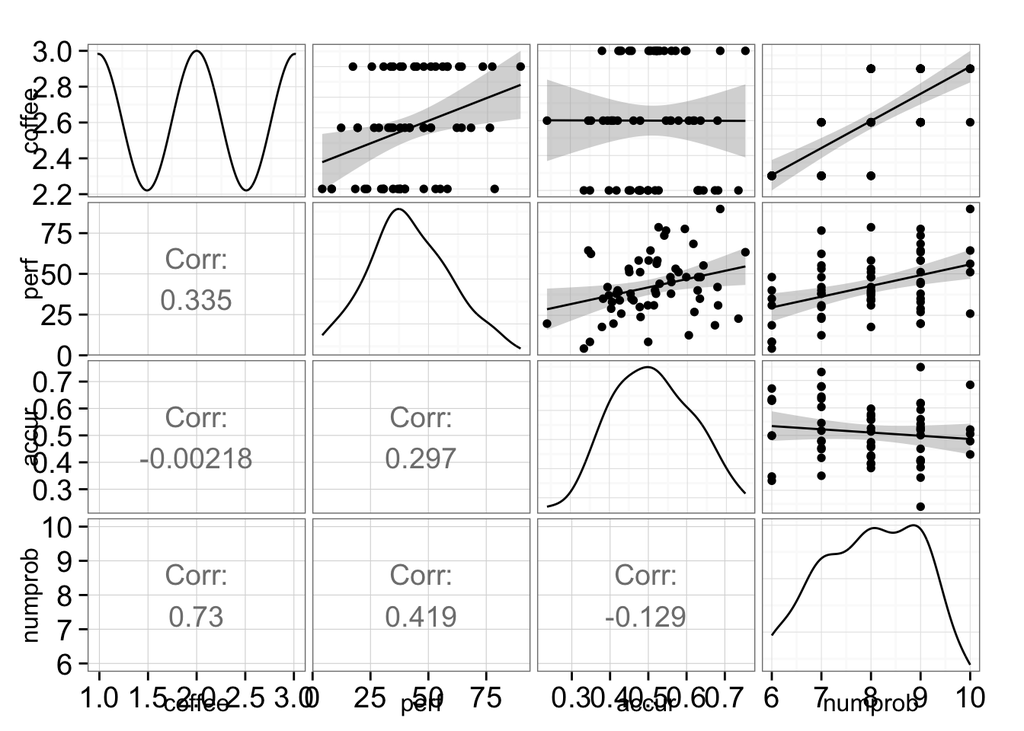

```r
plot_dataframe(d)
```

```r
table(d$coffee)
```

```
##
##  1  2  3
## 20 20 20
```

We should probably recode coffee cups into number of coffee cups!

```r
summary(d)
```

```
##      coffee       perf          accur          numprob
##  Min.   :1   Min.   : 5.0   Min.   :0.240   Min.   : 6.00
##  1st Qu.:1   1st Qu.:31.0   1st Qu.:0.426   1st Qu.: 7.00
##  Median :2   Median :40.0   Median :0.510   Median : 8.00
##  Mean   :2   Mean   :42.4   Mean   :0.511   Mean   : 7.95
##  3rd Qu.:3   3rd Qu.:53.5   3rd Qu.:0.594   3rd Qu.: 9.00
##  Max.   :3   Max.   :89.0   Max.   :0.749   Max.   :10.00
##  NA's   :2   NA's   :2      NA's   :2       NA's   :2
```

```r
d$cups = 0*as.numeric(d$coffee==1) + 2*as.numeric(d$coffee==2) + 4*as.numeric(d$coffee==3)
table(d$cups)
```

```
##
##  0  2  4
## 20 20 20
```

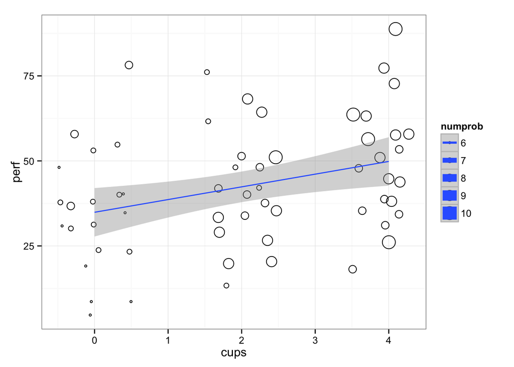

```r
ggplot(d,
       aes(x=cups,
           y=perf, size=numprob)) +  # Adding color for mentill
  geom_point(shape=1, position=position_jitter(width=.5)) +
  geom_smooth(method=lm, se=TRUE) +
  theme_bw()
```

First question: Does the number of problems attempted (hyperactivity) mediate the effect of coffee on performance? What is our x (IV)? Our y (DV)? Our mediator?

We need to run three models. There is one model that we never run (the effect of the mediator on the DV, without the IV included):

```r
with(d, summary(lm(perf~numprob)))
```

```
##
## Call:
## lm(formula = perf ~ numprob)
##
## Residuals:
##    Min     1Q Median     3Q    Max
## -29.66 -11.30  -0.17  10.28  39.79
##
## Coefficients:
##             Estimate Std. Error t value Pr(>|t|)
## (Intercept)    -9.17      14.84   -0.62  0.53898
## numprob         6.48       1.85    3.51  0.00087 ***
## ---
## Signif. codes:  0 '***' 0.001 '**' 0.01 '*' 0.05 '.' 0.1 ' ' 1
##
## Residual standard error: 16.8 on 58 degrees of freedom
##   (2 observations deleted due to missingness)
## Multiple R-squared:  0.175,  Adjusted R-squared:  0.161
## F-statistic: 12.3 on 1 and 58 DF,  p-value: 0.000872
```

The first model we need to look at is the direct path, does coffee predict performance? If not, we can abandon this whole endeavor!

```r
problm1<-lm(perf~cups,data=d)
summary(problm1) # yes, it predicts, c=3.74
```

```
##
## Call:
## lm(formula = perf ~ cups, data = d)
##
## Residuals:
##    Min     1Q Median     3Q    Max
## -31.84 -11.85  -0.37   8.63  43.11
##
## Coefficients:
##             Estimate Std. Error t value Pr(>|t|)
## (Intercept)    34.89       3.56    9.80  6.4e-14 ***
## cups            3.74       1.38    2.71   0.0088 **
## ---
## Signif. codes:  0 '***' 0.001 '**' 0.01 '*' 0.05 '.' 0.1 ' ' 1
##
## Residual standard error: 17.4 on 58 degrees of freedom
##   (2 observations deleted due to missingness)
## Multiple R-squared:  0.112,  Adjusted R-squared:  0.0972
## F-statistic: 7.35 on 1 and 58 DF,  p-value: 0.0088
```

```r
c<-problm1$coefficients[2]; c # We'll save our coefficients for our Sobel test later!
```

```
##  cups
## 3.738
```

```r
problm1<-lm(perf~coffee,data=d) # Note that we get the same results whether we recode coffee or not, just different coefficients
summary(problm1)
```

```
##
## Call:
## lm(formula = perf ~ coffee, data = d)
##
## Residuals:
##    Min     1Q Median     3Q    Max
## -31.84 -11.85  -0.37   8.63  43.11
##
## Coefficients:
##             Estimate Std. Error t value Pr(>|t|)
## (Intercept)    27.42       5.96    4.60  2.3e-05 ***
## coffee          7.47       2.76    2.71   0.0088 **
## ---
## Signif. codes:  0 '***' 0.001 '**' 0.01 '*' 0.05 '.' 0.1 ' ' 1
##
## Residual standard error: 17.4 on 58 degrees of freedom
##   (2 observations deleted due to missingness)
## Multiple R-squared:  0.112,  Adjusted R-squared:  0.0972
## F-statistic: 7.35 on 1 and 58 DF,  p-value: 0.0088
```

Now let’s check out Model 2, whether the IV affects the mediator, in other words, does coffee predict the number of problems attempted?

```r
problm2<-lm(numprob~cups,data=d)
summary(problm2) # yes, a=0.52
```

```
##
## Call:
## lm(formula = numprob ~ cups, data = d)
##
## Residuals:
##    Min     1Q Median     3Q    Max
##  -1.00  -0.90   0.05   1.00   2.05
##
## Coefficients:
##             Estimate Std. Error t value Pr(>|t|)
## (Intercept)   6.9000     0.1668   41.36  < 2e-16 ***
## cups          0.5250     0.0646    8.12  3.8e-11 ***
## ---
## Signif. codes:  0 '***' 0.001 '**' 0.01 '*' 0.05 '.' 0.1 ' ' 1
##
## Residual standard error: 0.817 on 58 degrees of freedom
##   (2 observations deleted due to missingness)
## Multiple R-squared:  0.532,  Adjusted R-squared:  0.524
## F-statistic:   66 on 1 and 58 DF,  p-value: 3.79e-11
```

```r
a<-summary(problm2)$coefficients[2,1]; a
```

```
## [1] 0.525
```

```r
s_a<-summary(problm2)$coefficients[2,2]; s_a
```

```
## [1] 0.06462
```

Our final model, Model 3, is the effect of coffee on performance mediated by the effect of the number of problems.

```r
problm3<-lm(perf~cups+numprob,data=d)
summary(problm3)
```

```
##
## Call:
## lm(formula = perf ~ cups + numprob, data = d)
##
## Residuals:
##    Min     1Q Median     3Q    Max
## -29.60 -11.56  -0.13   9.26  39.10
##
## Coefficients:
##             Estimate Std. Error t value Pr(>|t|)
## (Intercept)   -4.843     19.087   -0.25    0.801
## cups           0.714      1.958    0.36    0.717
## numprob        5.759      2.721    2.12    0.039 *
## ---
## Signif. codes:  0 '***' 0.001 '**' 0.01 '*' 0.05 '.' 0.1 ' ' 1
##
## Residual standard error: 16.9 on 57 degrees of freedom
##   (2 observations deleted due to missingness)
## Multiple R-squared:  0.177,  Adjusted R-squared:  0.148
## F-statistic: 6.14 on 2 and 57 DF,  p-value: 0.00386
```

```r
c_prime<-summary(problm3)$coefficients[2,1]; c_prime
```

```
## [1] 0.7142
```

```r
b<-summary(problm3)$coefficients[3,1]; b
```

```
## [1] 5.759
```

```r
s_b<-summary(problm3)$coefficients[3,2]; s_b
```

```
## [1] 2.721
```

```r
# note, we can also get c_prime by subtracting a * b from our original c:
c_prime
```

```
## [1] 0.7142
```

```r
c - a*b
```

```
##   cups
## 0.7142
```

The direct effect of coffee (c) disappeared and the number of problems attempted (b) is significant. We could answer yes, there is mediation, but let’s be more formal.

Let’s perform the conventional Sobel test, adding in the standard error of a and standard error of b.

```r
s_ab <- sqrt(b^2*s_a^2+a^2*s_b^2+s_a^2*s_b^2)
s_ab # standard error of a*b
```

```
## [1] 1.486
```

```r
a*b
```

```
## [1] 3.023
```

```r
a*b/s_ab
```

```
## [1] 2.034
```

```r
p_s_ab<-pnorm(a*b/s_ab, lower.tail=F)
p_s_ab # p of ratio of a*b over its s.e.
```

```
## [1] 0.02098
```

Now let’s repeat the procedure for the second mediation analysis. The question now is: does accuracy meadiate the effect of coffee on performance?

We did Model 1 above and have significant c (the direct path)

Now let’s move on to Model 2, does coffee predict accuracy?

```r
accurm2<-lm(accur~cups,data=d)
summary(accurm2)
```

```
##
## Call:
## lm(formula = accur ~ cups, data = d)
##
## Residuals:
##      Min       1Q   Median       3Q      Max
## -0.27062 -0.08471 -0.00076  0.08388  0.23812
##
## Coefficients:
##              Estimate Std. Error t value Pr(>|t|)
## (Intercept)  0.511140   0.022174   23.05   <2e-16 ***
## cups        -0.000143   0.008588   -0.02     0.99
## ---
## Signif. codes:  0 '***' 0.001 '**' 0.01 '*' 0.05 '.' 0.1 ' ' 1
##
## Residual standard error: 0.109 on 58 degrees of freedom
##   (2 observations deleted due to missingness)
## Multiple R-squared:  4.77e-06,   Adjusted R-squared:  -0.0172
## F-statistic: 0.000277 on 1 and 58 DF,  p-value: 0.987
```

No, coffee consumption does not predict accuracy, so according to Baron & Kenny we can stop and conclude there is no mediation. But lets procede, using a=-0.00014.

```r
a2<-summary(accurm2)$coefficients[2,1]
s_a2<-summary(accurm2)$coefficients[2,2]
```

Now model 3, is the effect of coffee on performance mediated by the effect of accuracy?

```r
accurm3<-lm(perf~cups+accur,data=d)
summary(accurm3) # now the effect of coffee remains as well as an effect of accur.
```

```
##
## Call:
## lm(formula = perf ~ cups + accur, data = d)
##
## Residuals:
##    Min     1Q Median     3Q    Max
## -34.08  -9.88  -0.83   7.82  42.35
##
## Coefficients:
##             Estimate Std. Error t value Pr(>|t|)
## (Intercept)     8.93      10.86    0.82   0.4144
## cups            3.74       1.32    2.84   0.0063 **
## accur          50.80      20.17    2.52   0.0146 *
## ---
## Signif. codes:  0 '***' 0.001 '**' 0.01 '*' 0.05 '.' 0.1 ' ' 1
##
## Residual standard error: 16.7 on 57 degrees of freedom
##   (2 observations deleted due to missingness)
## Multiple R-squared:  0.201,  Adjusted R-squared:  0.173
## F-statistic: 7.19 on 2 and 57 DF,  p-value: 0.00165
```

```r
b2<-summary(accurm3)$coefficients[3,1]
s_b2<-summary(accurm3)$coefficients[3,2]
```

Perform conventional sobel test, adding standard error of a and b.

```r
s_ab2 <- sqrt(b2^2*s_a2^2+a2^2*s_b2^2+s_a2^2*s_b2^2)
s_ab2 # standard error of a*b
```

```
## [1] 0.4694
```

```r
p_s_ab2<-pnorm(a2*b2/s_ab2,lower.tail=F)
p_s_ab2 # p of ratio of a2*b2 over its s.e.
```

```
## [1] 0.5062
```

Conclusion: Coffee and accuracy both contribute to performance and in this case there is no mediation there. However, the effect of coffee is mediated by the number of problems attempted.

## Bootstrapped Mediation

Using a modified version of Benoit’s script, let’s re-run the analysis from before:

```r
mediation_bootstrap = function(x, med, y, iterations = 1000){

  # setup some parameters
  N = length(x)
  df = as.data.frame(cbind(x, med, y))
  boot_ab = vector(length=iterations) # set up empty vector for storage

  # now go through a loop where we'll randomly sample, and get a a*b value
  for (i in 1:iterations){
    ind_boot = sample(c(1:N), N, replace=TRUE) # random indices
    df_boot = df[ind_boot,]

    iter_a = lm(df_boot$med ~ df_boot$x)$coefficients[2] # coeff of x
    iter_b = lm(df_boot$y ~ df_boot$med + df_boot$x)$coefficients[2] # coeff of mediator

    boot_ab[i] = iter_a * iter_b
  }

  # create plot
  hist(boot_ab,main=paste("Bootstrapped a*b, with",iterations,"iterations"),col="red");
  abline(v=0, col='black', lty=2, lwd=2)
  abline(v=c(quantile(boot_ab,c(.025,.975))), col='blue', lty=3)

  # Print results
  print("Bootstrap results:",quote=F);
  print(c(ab=mean(boot_ab)));
  print(quantile(boot_ab,c(.025,.975)))

  return(boot_ab)
}
```

```r
boot_ab = mediation_bootstrap(x=d$cups, med=d$numprob, y=d$perf, iterations=10000)
```

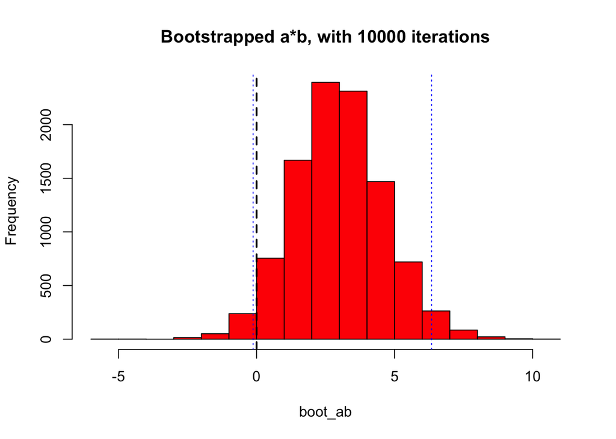

```
## [1] Bootstrap results:
##    ab
## 2.984
##    2.5%   97.5%
## -0.1258  6.3390
```

```r
mean(boot_ab)
```

```
## [1] 2.984
```

```r
# compared to our ab from before:
a*b
```

```
## [1] 3.023
```